# Intro_en_R

# Nisrine Bennor

## Chapitre 1

#### Importation du fichier smp1.csv

library(readr)

#### Définir lerépertoire du travail

setwd(“~/Documents/INTRO_Stat_FunMooc_Nisrine”)

#### Impoter le fichier csv

smp <- read_csv2(“smp1.csv”)

#### Voir le fichier csv

str(smp)

str(smp$prof)

#### Le nombre des détenus ayant chacun un métiers

table(smp$prof)

#### Présentation des resultats par un diagramme en batôns

barplot(table(smp$prof))

#### Présentation des resultats par un diagramme en batôns

barplot(table(smp$prof))

[figure not shown]

#### Présentation des résultats par un diagramme en batôns

barplot(table(smp$prof))

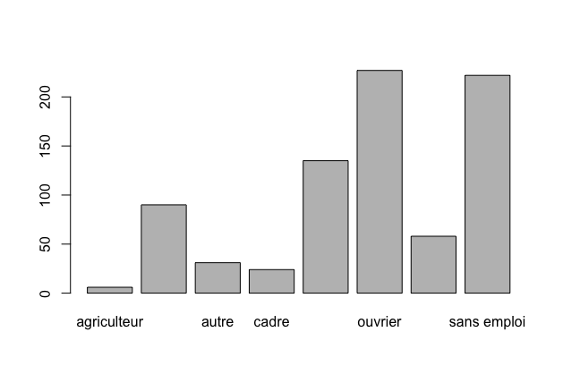

#### présentation des résultats par un Camanbert

pie(table(smp$prof))

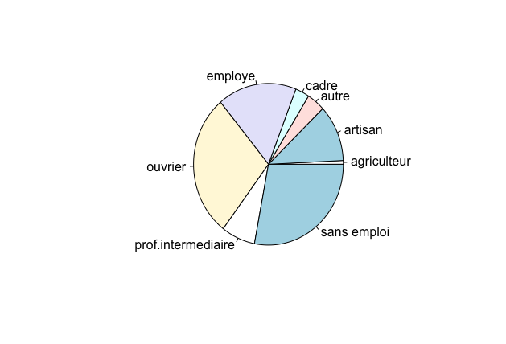

#### Présentation des nombres des détenues en fonction de leur age

hist(smp$age)

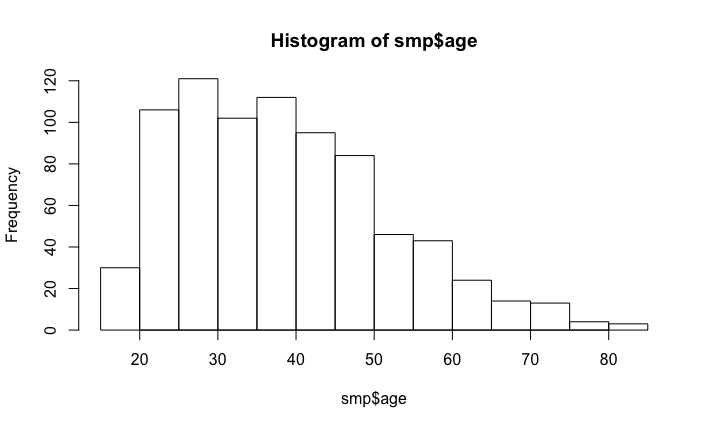

#### Griser les batons ou colorier les batôns de l’hist

hist(smp$age, col = “grey”, main = "“, xlab =”age")

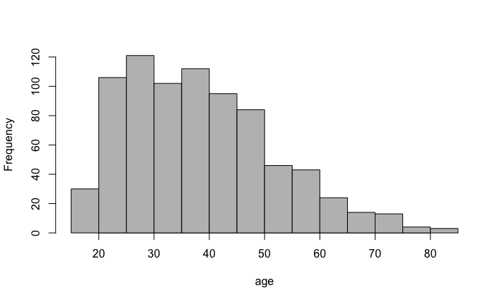

#### Boite à moustache

boxplot(smp$age, xlab= “age”)

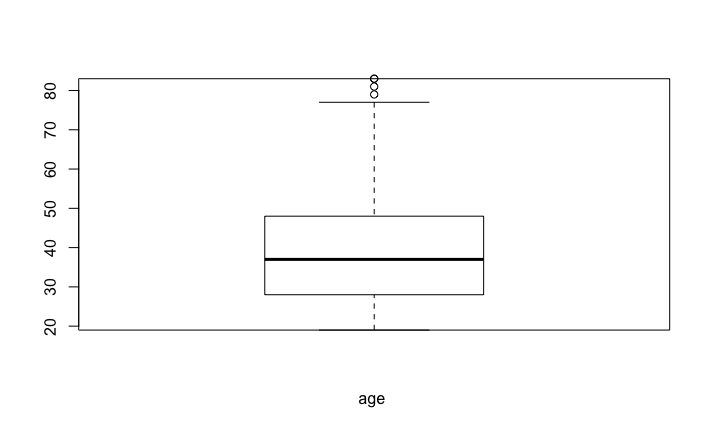

#### La distribution de l’âge en fonction du niveau de recherche de sensation

boxplot(smp$age~smp$rs , ylab = “age”, xlab = “Recherche de sensation”)

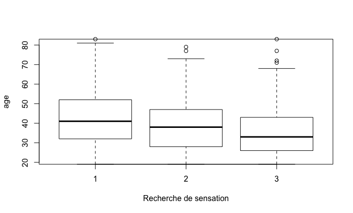

#### répresenter la distribution conjointe de é variables quantitatives

plot(jitter(smp$age), jitter(smp$n.enfant), xlab=“age”, ylab=“n.enfant”)

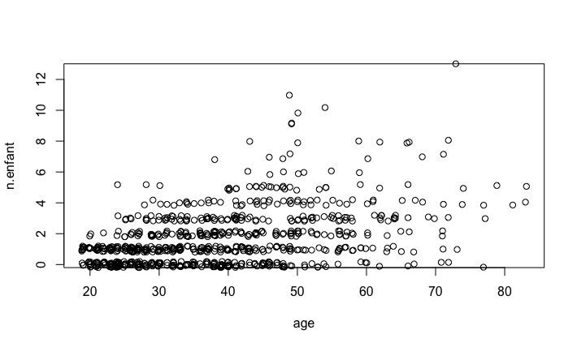

#### Diagramme temporel

install.packages(“gplots”) library(gplots) hdrs <- read_csv2(“outils_hdrs.csv”) plotmeans(hdrs$HDRS~hdrs$VISIT, barcol =“black”, gap=0)

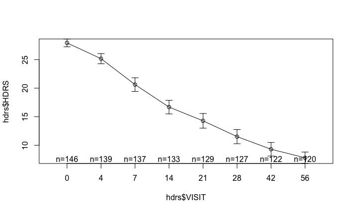

#### Diagramme en fagot : l’évoloution moyenne des sujets au cours du temps par rapport à l’HDRS

interaction.plot(hdrs$VISIT, hdrs$NUMERO, hdrs$HDRS, lty = 1, legend = FALSE)

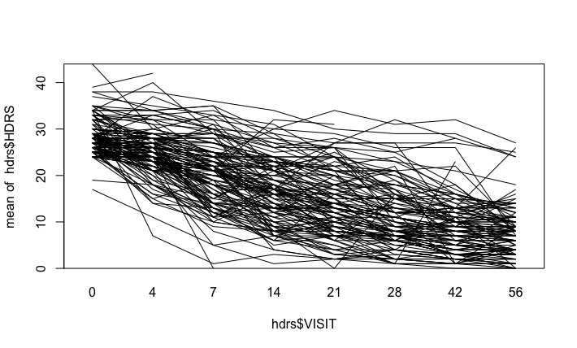

#### calculer les mesures de position et de dispersion

summary(smp)

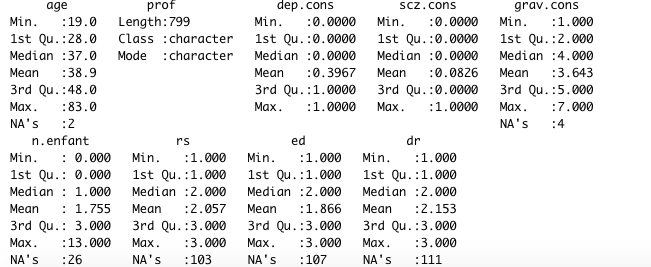

#### calculer les mesures de position et de dispersion install.packages(“prettyR”) library(prettyR) describe(smp)

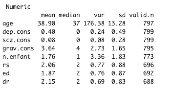

describe(smp, num.desc = c(“mean”, “sd”, “valid.n”, “median”, “min”, “max”))

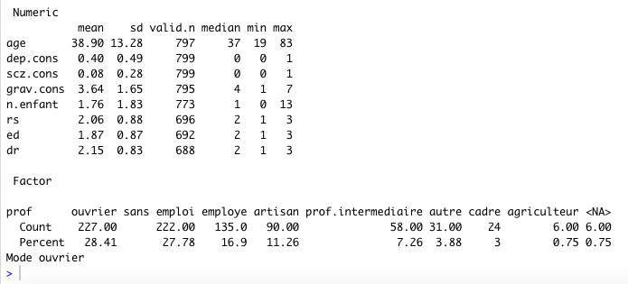

#### calculer la moyenne des ages

mean(smp$age, na.rm = TRUE)  
[1] 38.89962

#### calculer l’écart-type des ages

sd(smp$age, na.rm = TRUE)  
[1] 13.28098

#### savoir les nombres de sujet pour chaque profession

table(smp$prof, deparse.level = 2, useNA = “always”)

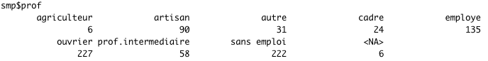

## Gestion des données.dataframes.variables catégorielles

setwd(“~/INTRO_Stat_FunMooc_Nisrine”)  
smp <- read_csv2(“smp1.csv”)

#### Voir le fichier smp

View(smp)

#### Les noms des variables des fichiers smp

names(smp)

str(smp)

#### ensemble des observations

smp$age

#### afficher une seul abservation

smp$age[1]  
[1] 31

#### afficher de la 1er à la 10eme observation

smp$age[1:10]  
[1] 31 49 50 47 23 34 24 52 42 45

#### valeur minimal de l’age

min(smp$age)

help(min)

min(smp$age, na.rm = TRUE)

[1] 19

#### les variables binaires

smp$scz.cons[1:10]  
[1] 0 0 0 0 0 0 0 0 0 0

unique(smp$scz.cons)  
[1] 0 1

#### afficher les 10 permières valeurs

head(smp$scz.cons, n=10)  
[1] 0 0 0 0 0 0 0 0 0 0

#### nombre d’obs

length(smp$scz.cons)  
[1] 799

#### nombre de ligne du tableau smp

nrow(smp)  
[1] 799

#### nombre d’affectifs associées à chacune des modalités

table(smp$scz.cons)  
0 1  
733 66

table(smp$scz.cons, useNa=“always”)  
0 1  
733 66 0

#### variable catégorielle binaire

head(factor(smp$scz.cons))

[1] 0 0 0 0 0 0  
Levels: 0 1

abus <- factor(smp$scz.cons, levels = c(0,1), labels = c(“Non”, “Oui”)) table(abus)

abus  
Non Oui  
733 66

table(abus, useNA = “always”)  
abus  
Non Oui  
733 66 0

#### on prend une autre variable quanlitative : n.enfant

head(smp$n.enfant)  
[1] 2 7 2 0 1 3

summary(smp$n.enfant)  
Min. 1st Qu. Median Mean 3rd Qu. Max. NA’s  
0.000 0.000 1.000 1.755 3.000 13.000 26

#### regardant la répartition de l’effectif

table(smp$n.enfant)  
0 1 2 3 4 5 6 7 8 9 10 11 13  
214 220 125 101 55 31 7 7 7 2 2 1 1

#### Nombre d’enfants > 4

table(smp$n.enfant > 4)

FALSE TRUE  
715 58

#### création de variable qualitative

smp$n.enfant.cat <- factor(smp$n.enfant)  
table(smp$n.enfant.cat)

levels(smp$n.enfant.cat)  
[1] “0” “1” “2” “3” “4” “5” “6” “7” “8” “9” “10” “11” “13”

nlevels(smp$n.enfant.cat) == 13

#### changer de d’obs

levels(smp$n.enfant.cat)[6:13] <- “5+”

table(smp$n.enfant.cat)  
0 1 2 3 4 5+  
214 220 125 101 55 58

## Indexation criteriés d’obsreations, sélection de variables, graphiques suivantes

### variables quantitatives

names(smp)  
smp$age[1] ==> 31  
smp[1,1] ==> 31  
smp[1,“age”] ==> 31

### variables qualitatives

head(smp$prof)

head(smp$prof==“agriculteur”)  
[1] FALSE NA FALSE FALSE FALSE FALSE

table(smp$prof == “agriculteur”)  
FALSE TRUE  
787 6

#### savoir quel obs remplie les conditions

which(smp$prof==“agriculteur”)  
[1] 15 312 384 391 439 442

#### indexer les variables d’age pour lesquelles la profession == “agriculteur”

smp$age[which(smp$prof == “agriculteur”)] [1] 64 42 37 36 35 79

#### indexer les variables d’age pour lesquelles la profession == “agriculteur” avec la fonction subset

subset(smp, prof == “agriculteur”, age)

subset(smp, prof == “agriculteur”, 1:5)

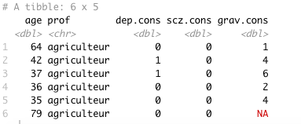

names(smp) subset(smp, prof == “agriculteur”, c(“age”, “dep.cons”, “scz.cons”, “grav.cons”) )

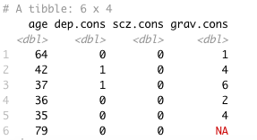

#### Rajouter des filtres subset(smp, prof == “agriculteur” & n.enfant > 2, c(age, dep.cons, scz.cons, grav.cons) )

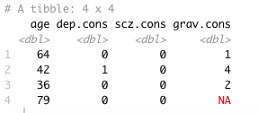

#### Rajouter des filtres

subset(smp, prof == “agriculteur” & n.enfant > 2, c(age, dep.cons, scz.cons, grav.cons) )

#### effectier des opérations sur tab

sum(tab)  
[1] 773

tab / sum(tab)  
0 1 2 3 4 5+  
0.27684347 0.28460543 0.16170763 0.13065977 0.07115136 0.07503234